# Classification

classification

Alireza Darvishi

2020-08-13 23:35:03

# Loading data and packages

```r
library(readxl)
library(tidyverse)
library(glmnet)
library(verification)
library(MASS)
data <- read_excel("default of credit card clients.xls")
head(data)
```

```
## # A tibble: 6 x 25
##      ID LIMIT_BAL   SEX EDUCATION MARRIAGE   AGE PAY_1 PAY_2 PAY_3 PAY_4 PAY_5
##   <dbl>     <dbl> <dbl>     <dbl>    <dbl> <dbl> <dbl> <dbl> <dbl> <dbl> <dbl>
## 1     1     20000     2         2        1    24     3     3     0     0    -1
## 2     2    120000     2         2        2    26     0     3     1     1     1
## 3     3     90000     2         2        2    34     1     1     1     1     1
## 4     4     50000     2         2        1    37     1     1     1     1     1
## 5     5     50000     1         2        1    57     0     1     0     1     1
## 6     6     50000     1         1        2    37     1     1     1     1     1
## # … with 14 more variables: PAY_6 <dbl>, BILL_AMT1 <dbl>, BILL_AMT2 <dbl>,
## #   BILL_AMT3 <dbl>, BILL_AMT4 <dbl>, BILL_AMT5 <dbl>, BILL_AMT6 <dbl>,
## #   PAY_AMT1 <dbl>, PAY_AMT2 <dbl>, PAY_AMT3 <dbl>, PAY_AMT4 <dbl>,
## #   PAY_AMT5 <dbl>, PAY_AMT6 <dbl>, def_pymnt_nxt_mnth <dbl>
```

# Data description

This research employed a binary variable, default payment (Yes = 1, No = 0), as the response variable. This study used the following 23 variables as explanatory variables

Amount of the given credit (NT dollar): it includes both the individual consumer credit and his/her family (supplementary) credit.

Gender (1 = male; 2 = female).

Marital status (0 = unknown; 1 = married; 2 = single; 3 = others).

Age (year).

PAY_1 - PAY_6 : History of past payment. We tracked the past monthly payment records (from April to September, 2005) as follows: PAY_1 = the repayment status in September, 2005; PAY_2 = the repayment status in August, 2005; . . .;PAY_6 = the repayment status in April, 2005. The measurement scale for the repayment status is: -1 = pay duly; 1 = payment delay for one month; 2 = payment delay for two months; . . .; 8 = payment delay for eight months; 9 = payment delay for nine months and above.

Amount of bill statement (NT dollar). BIL_AMT1 = amount of bill statement in September, 2005; BIL_AMT2 = amount of bill statement in August, 2005; . . .; BIL_AMT6 = amount of bill statement in April, 2005.

Amount of previous payment (NT dollar). PAY_AMT1 = amount paid in September, 2005; PAY_AMT2 = amount paid in August, 2005; . . .;PAY_AMT6 = amount paid in April, 2005.

## Preprocess and data summary

```r
data$SEX = as.factor(data$SEX)
data$EDUCATION = as.factor(data$EDUCATION)
data$MARRIAGE = as.factor(data$MARRIAGE)
data$def_pymnt_nxt_mnth = as.factor(data$def_pymnt_nxt_mnth)
summary(data[,-1])
```

```
##    LIMIT_BAL         SEX          EDUCATION     MARRIAGE          AGE
##  Min.   :  10000   1   :11888   2      :14030   0   :   54   Min.   :21.00
##  1st Qu.:  50000   2   :18112   1      :10585   1   :13659   1st Qu.:28.00
##  Median : 140000   NA's:35535   3      : 4917   2   :15964   Median :34.00
##  Mean   : 167484                5      :  280   3   :  323   Mean   :35.49
##  3rd Qu.: 240000                4      :  123   NA's:35535   3rd Qu.:41.00
##  Max.   :1000000                (Other):   65                Max.   :79.00
##  NA's   :35535                  NA's   :35535                NA's   :35535
##      PAY_1             PAY_2             PAY_3             PAY_4
##  Min.   :-1.0000   Min.   :-1.0000   Min.   :-1.0000   Min.   :-1.000
##  1st Qu.: 1.0000   1st Qu.: 1.0000   1st Qu.: 1.0000   1st Qu.: 1.000
##  Median : 1.0000   Median : 1.0000   Median : 1.0000   Median : 1.000
##  Mean   : 0.9924   Mean   : 0.9388   Mean   : 0.9239   Mean   : 0.899
##  3rd Qu.: 1.0000   3rd Qu.: 1.0000   3rd Qu.: 1.0000   3rd Qu.: 1.000
##  Max.   : 9.0000   Max.   : 9.0000   Max.   : 9.0000   Max.   : 9.000
##
##      PAY_5             PAY_6           BILL_AMT1         BILL_AMT2
##  Min.   :-1.0000   Min.   :-1.0000   Min.   :-165580   Min.   :-69777
##  1st Qu.: 1.0000   1st Qu.: 1.0000   1st Qu.:   3559   1st Qu.:  2985
##  Median : 1.0000   Median : 1.0000   Median :  22382   Median : 21200
##  Mean   : 0.8781   Mean   : 0.8667   Mean   :  51223   Mean   : 49179
##  3rd Qu.: 1.0000   3rd Qu.: 1.0000   3rd Qu.:  67091   3rd Qu.: 64006
##  Max.   : 9.0000   Max.   : 9.0000   Max.   : 964511   Max.   :983931
##                                      NA's   :35535     NA's   :35535
##    BILL_AMT3         BILL_AMT4         BILL_AMT5        BILL_AMT6
##  Min.   :-157264   Min.   :-170000   Min.   :-81334   Min.   :-339603
##  1st Qu.:   2666   1st Qu.:   2327   1st Qu.:  1763   1st Qu.:   1256
##  Median :  20088   Median :  19052   Median : 18104   Median :  17071
##  Mean   :  47013   Mean   :  43263   Mean   : 40311   Mean   :  38872
##  3rd Qu.:  60165   3rd Qu.:  54506   3rd Qu.: 50190   3rd Qu.:  49198
##  Max.   :1664089   Max.   : 891586   Max.   :927171   Max.   : 961664
##  NA's   :35535     NA's   :35535     NA's   :35535    NA's   :35535
##     PAY_AMT1         PAY_AMT2          PAY_AMT3         PAY_AMT4
##  Min.   :     0   Min.   :      0   Min.   :     0   Min.   :     0
##  1st Qu.:  1000   1st Qu.:    833   1st Qu.:   390   1st Qu.:   296
##  Median :  2100   Median :   2009   Median :  1800   Median :  1500
##  Mean   :  5664   Mean   :   5921   Mean   :  5226   Mean   :  4826
##  3rd Qu.:  5006   3rd Qu.:   5000   3rd Qu.:  4505   3rd Qu.:  4013
##  Max.   :873552   Max.   :1684259   Max.   :896040   Max.   :621000
##  NA's   :35535    NA's   :35535     NA's   :35535    NA's   :35535
##     PAY_AMT5           PAY_AMT6        def_pymnt_nxt_mnth
##  Min.   :     0.0   Min.   :     0.0   0   :23364
##  1st Qu.:   252.5   1st Qu.:   117.8   1   : 6636
##  Median :  1500.0   Median :  1500.0   NA's:35535
##  Mean   :  4799.4   Mean   :  5215.5
##  3rd Qu.:  4031.5   3rd Qu.:  4000.0
##  Max.   :426529.0   Max.   :528666.0
##  NA's   :35535      NA's   :35535
```

# Visualization

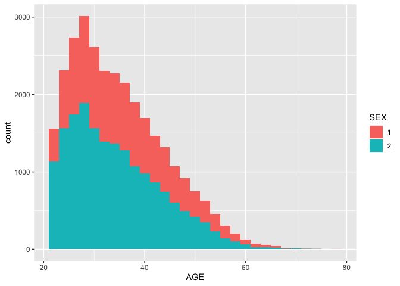

```r
ggplot(data) +
  geom_histogram(
    aes(x=AGE,fill = SEX),
    bins = 30)
```

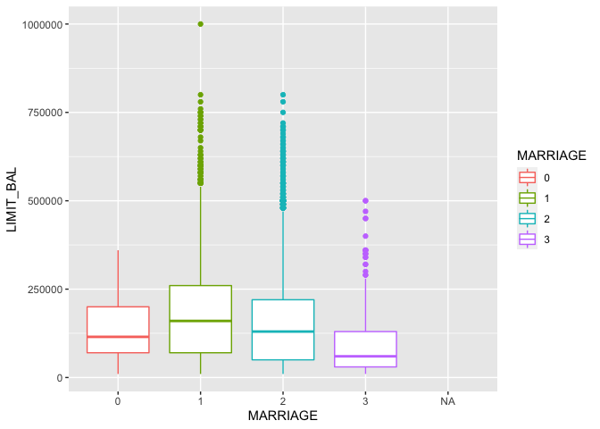

```r
ggplot(data) +
  geom_boxplot(
    aes(y=LIMIT_BAL,
        color = MARRIAGE , x = MARRIAGE))
```

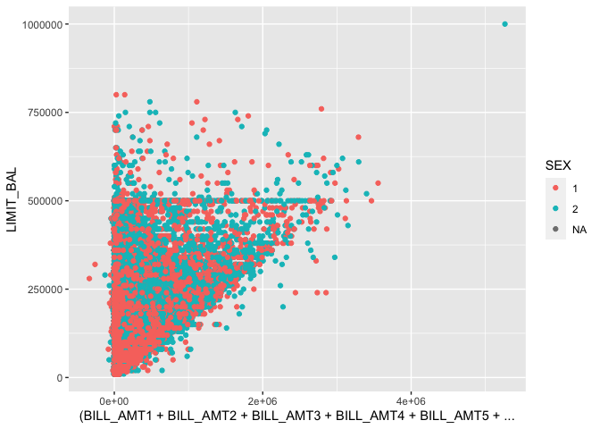

```r
ggplot(data) +
  geom_point(
    aes(color = SEX ,
        y=LIMIT_BAL,
        x = (BILL_AMT1+BILL_AMT2+BILL_AMT3+
               BILL_AMT4+BILL_AMT5+BILL_AMT6)))
```

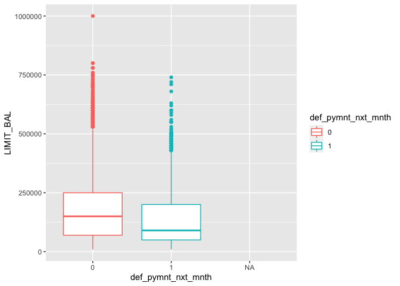

```r
ggplot(data) +
  geom_boxplot(
    aes(y=LIMIT_BAL,
        color = def_pymnt_nxt_mnth ,
        x = def_pymnt_nxt_mnth))
```

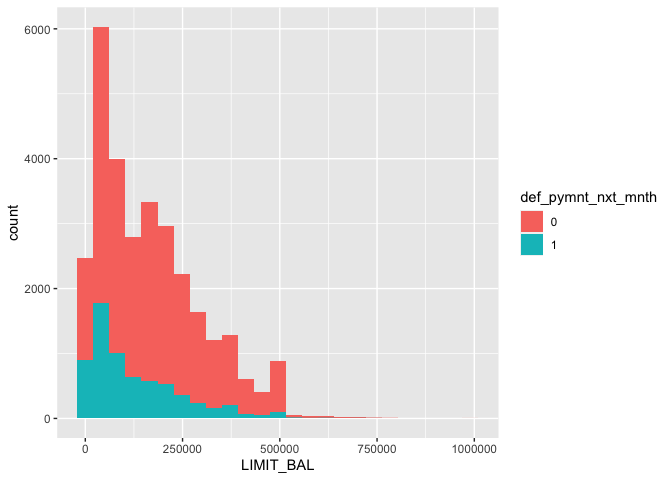

```r
ggplot(data) +
  geom_histogram(
    aes(fill = def_pymnt_nxt_mnth ,
        x = LIMIT_BAL),bins=25)
```

# Data manipulation

```r
data = na.omit(data)
cor(data[,7:12])
```

```
##           PAY_1     PAY_2     PAY_3     PAY_4     PAY_5     PAY_6
## PAY_1 1.0000000 0.6721644 0.5742451 0.5388406 0.5094261 0.4745531
## PAY_2 0.6721644 1.0000000 0.7665517 0.6620671 0.6227802 0.5755009
## PAY_3 0.5742451 0.7665517 1.0000000 0.7773589 0.6867745 0.6326836
## PAY_4 0.5388406 0.6620671 0.7773589 1.0000000 0.8198353 0.7164495
## PAY_5 0.5094261 0.6227802 0.6867745 0.8198353 1.0000000 0.8169002
## PAY_6 0.4745531 0.5755009 0.6326836 0.7164495 0.8169002 1.0000000
```

```r
cor(data[,13:18])
```

```
##           BILL_AMT1 BILL_AMT2 BILL_AMT3 BILL_AMT4 BILL_AMT5 BILL_AMT6
## BILL_AMT1 1.0000000 0.9514837 0.8922785 0.8602722 0.8297786 0.8026502
## BILL_AMT2 0.9514837 1.0000000 0.9283263 0.8924823 0.8597783 0.8315936
## BILL_AMT3 0.8922785 0.9283263 1.0000000 0.9239695 0.8839097 0.8533201
## BILL_AMT4 0.8602722 0.8924823 0.9239695 1.0000000 0.9401344 0.9009410
## BILL_AMT5 0.8297786 0.8597783 0.8839097 0.9401344 1.0000000 0.9461968
## BILL_AMT6 0.8026502 0.8315936 0.8533201 0.9009410 0.9461968 1.0000000
```

```r
cor(data[,19:24])
```

```
##           PAY_AMT1  PAY_AMT2  PAY_AMT3  PAY_AMT4  PAY_AMT5  PAY_AMT6
## PAY_AMT1 1.0000000 0.2855755 0.2521911 0.1995579 0.1484593 0.1857353
## PAY_AMT2 0.2855755 1.0000000 0.2447705 0.1801067 0.1809078 0.1576339
## PAY_AMT3 0.2521911 0.2447705 1.0000000 0.2163251 0.1592137 0.1627400
## PAY_AMT4 0.1995579 0.1801067 0.2163251 1.0000000 0.1518304 0.1578339
## PAY_AMT5 0.1484593 0.1809078 0.1592137 0.1518304 1.0000000 0.1548955
## PAY_AMT6 0.1857353 0.1576339 0.1627400 0.1578339 0.1548955 1.0000000
```

As we can see PAYs are correlated with each other and BILLs are correlated with each other as well.

So we summarise these data to lower dimension using linear transformations below.

But PAY_AMTs are not correlated so we keep theme and regularize it with credit limit value.

```r
data %>% mutate(PAY_AMT_SUM=
                  PAY_1*PAY_AMT1+PAY_2*PAY_AMT2+
                  PAY_3*PAY_AMT3+PAY_4*PAY_AMT4+
                  PAY_5*PAY_AMT5+PAY_6*PAY_AMT6 ,
                REGULARIZED_BILL =
                  PAY_1*BILL_AMT1 +PAY_2*BILL_AMT2 +
                  PAY_3*BILL_AMT3 +PAY_4*BILL_AMT4 +
                  PAY_5*BILL_AMT5 +PAY_6*BILL_AMT6 ,
                PAY_MEAN = PAY_1/6+PAY_2/6+PAY_3/6+
                  PAY_4/6+PAY_5/6+PAY_6/6 ,
                PAY_RATIO1 = PAY_AMT1/LIMIT_BAL ,
                PAY_RATIO2 = PAY_AMT2/LIMIT_BAL ,
                PAY_RATIO3 = PAY_AMT3/LIMIT_BAL ,
                PAY_RATIO4 = PAY_AMT4/LIMIT_BAL ,
                PAY_RATIO5 = PAY_AMT5/LIMIT_BAL ,
                PAY_RATIO6 = PAY_AMT6/LIMIT_BAL ) %>% .[-c(7:24,1)] -> new_data
train_idx = sample(30000,size = 0.8*30000)
train_data = new_data[train_idx,]
test_data = new_data[-train_idx,]
x = model.matrix(def_pymnt_nxt_mnth~., train_data)[,-1]
y <- ifelse(train_data$def_pymnt_nxt_mnth == 1, 1, 0)
x.test <- model.matrix(def_pymnt_nxt_mnth ~., test_data)[,-1]
y.test = ifelse(test_data$def_pymnt_nxt_mnth == 1, 1, 0)
```

# Model selection

In this section we fit Logistic Regression and LDA:

## Logistic Regression with lasso:

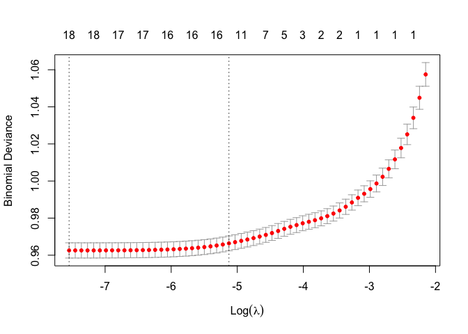

```r
cv.lasso <- cv.glmnet(x, y, alpha = 1, family = "binomial")
plot(cv.lasso)
```

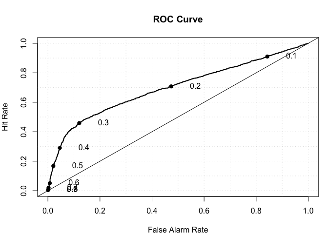

```r
LR.Lasso_model <- glmnet(x, y, alpha = 1, family = "binomial",
                lambda = cv.lasso$lambda.min)
pred.lr = predict(LR.Lasso_model,newx = x.test,type = "response")
roc.plot(y.test,pred.lr)
```

```r
thresh = 0.35
table(pred.lr>thresh,y.test)
```

```
##        y.test
##            0    1
##   FALSE 4373  832
##   TRUE   310  485
```

```r
mean((pred.lr>thresh) == y.test)
```

```
## [1] 0.8096667
```

```r
#roc_data = roc.glmnet(model,newx = x.test,newy = y.test, family = "binomial")
#ggplot(roc_data) + geom_line(aes(x= FPR,y=TPR)) + geom_abline(slope = 1)
```

## Logistic Regression with ridge:

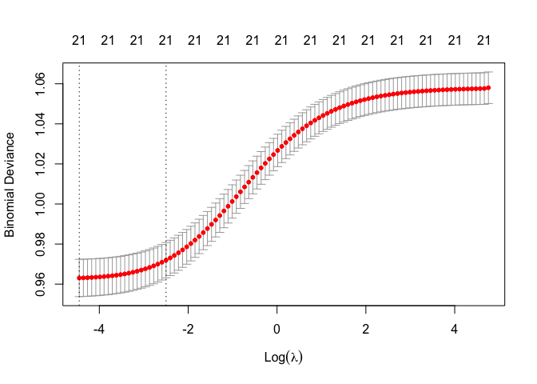

```r
cv.ridge <- cv.glmnet(x, y, alpha = 0, family = "binomial")
plot(cv.ridge)
```

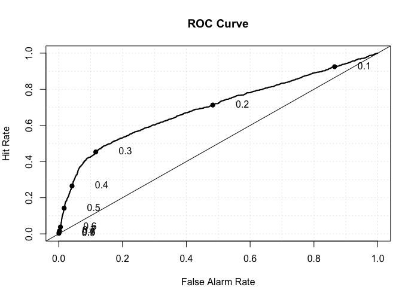

```r
LR.ridge_model <- glmnet(x, y, alpha = 0, family = "binomial",
                lambda = cv.ridge$lambda.min)
pred.lr = predict(LR.ridge_model,newx = x.test,type = "response")
roc.plot(y.test,pred.lr)
```

```r
thresh = 0.35
table(pred.lr>thresh,y.test)
```

```
##        y.test
##            0    1
##   FALSE 4398  853
##   TRUE   285  464
```

```r
mean((pred.lr>thresh) == y.test)
```

```
## [1] 0.8103333
```

```r
#roc_data = roc.glmnet(model,newx = x.test,newy = y.test, family = "binomial")
#ggplot(roc_data) + geom_line(aes(x= FPR,y=TPR)) + geom_abline(slope = 1)
```

## LDA:

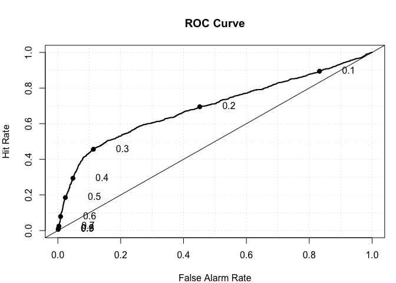

```r
lda.fit = lda(data = new_data , subset = train_idx , def_pymnt_nxt_mnth~.)
roc.plot(y.test,predict(lda.fit,newdata = test_data)$posterior[,2])
```

```r
pred.lda = predict(lda.fit,newdata = test_data)$class
table(pred.lda,y.test)
```

```
##         y.test
## pred.lda    0    1
##        0 4571 1073
##        1  112  244
```

```r
mean(pred.lda == y.test)
```

```
## [1] 0.8025
```

# Final results

Final Coefs are reported below:

```r
coef(LR.Lasso_model)
```

```
## 22 x 1 sparse Matrix of class "dgCMatrix"
##                             s0
## (Intercept)      -1.502158e+00
## LIMIT_BAL        -2.508332e-06
## SEX2             -1.278649e-01
## EDUCATION1        1.304246e-01
## EDUCATION2        .
## EDUCATION3        .
## EDUCATION4       -1.032312e+00
## EDUCATION5       -1.117660e+00
## EDUCATION6       -2.688859e-01
## MARRIAGE1         2.403820e-01
## MARRIAGE2         .
## MARRIAGE3         2.822545e-02
## AGE               2.778836e-03
## PAY_AMT_SUM      -1.633387e-06
## REGULARIZED_BILL  1.894526e-07
## PAY_MEAN          5.927940e-01
## PAY_RATIO1       -8.993834e-01
## PAY_RATIO2       -1.697311e+00
## PAY_RATIO3       -3.079127e-01
## PAY_RATIO4       -2.100676e-01
## PAY_RATIO5       -4.147444e-01
## PAY_RATIO6       -1.591236e-01
```